# Counts And Ordering

# Goal

This notebook shows how to visualize categorical counts and order categories so the plot answers a clearer question.

It also uses common data-preparation functions we will use throughout the course: `select()`, `count()`, `group_by()`, `summarize()`, `arrange()`, and `mutate()`.

# Analytic Questions

We will use a cleaned Census race/ethnicity dataset to ask:

- How many state-category observations appear for each race/ethnicity category?
- Which race/ethnicity categories account for the largest total population in this file?
- How does ordering change what the reader can see?

# Load Data

```r
census <- readr::read_csv("data/real/census_state_race_ethnicity_long.csv")
census |>
  glimpse()
```

```
Rows: 357
Columns: 8
$ state                           <chr> "CA", "CA", "CA", "CA", "CA", "CA", "C…
$ state_name                      <chr> "California", "California", "Californi…
$ rank                            <dbl> 1, 1, 1, 1, 1, 1, 1, 2, 2, 2, 2, 2, 2,…
$ total_population                <dbl> 39538223, 39538223, 39538223, 39538223…
$ race_ethnicity                  <chr> "American Indian and Alaska Native", "…
$ race_ethnicity_population       <dbl> 156085, 5978795, 2119286, 15579652, 13…
$ total_race_ethnicity_population <dbl> 37910501, 37910501, 37910501, 37910501…
$ share                           <dbl> 0.0041171970, 0.1577081506, 0.05590234…
```

Each observation is one race/ethnicity category within one state.

Here, “included” means the race/ethnicity categories present in this teaching file. Check the codebook before treating them as every possible category.

# Explore The Structure

Before plotting, use a small table to check the structure of the file.

| Data preparation step | Functions in this chunk |
| --- | --- |
| Count or summarize | `summarize()`; `n()`; `n_distinct()` |

```r
census |>
  summarize(
    observations = n(),
    states = n_distinct(state),
    categories = n_distinct(race_ethnicity)
  )
```

```
# A tibble: 1 × 3
  observations states categories
         <int>  <int>      <int>
1          357     51          7
```

Use `select()` when you want to inspect only the variables relevant to the next question.

```r
census |>
  rename(race_ethnicity_proportion = share) |>
  select(state_name, race_ethnicity, race_ethnicity_population, race_ethnicity_proportion) |>
  head()
```

```
# A tibble: 6 × 4
  state_name race_ethnicity        race_ethnicity_popul…¹ race_ethnicity_propo…²
  <chr>      <chr>                                  <dbl>                  <dbl>
1 California American Indian and …                 156085                0.00412
2 California Asian                                5978795                0.158
3 California Black                                2119286                0.0559
4 California Hispanic or Latino                  15579652                0.411
5 California Native Hawaiian and …                 138167                0.00364
6 California Other                                 223929                0.00591
# ℹ abbreviated names: ¹race_ethnicity_population, ²race_ethnicity_proportion
```

**Tip:** You can also use select to reorder a dataframe.

# Count Observations

First, count how many rows appear for each race/ethnicity category.

| Data preparation step | Functions in this chunk |
| --- | --- |
| Count or summarize | `count()` |

```r
category_counts <- census |>
  count(race_ethnicity, sort = TRUE)

category_counts
```

```
# A tibble: 7 × 2
  race_ethnicity                                 n
  <chr>                                      <int>
1 American Indian and Alaska Native             51
2 Asian                                         51
3 Black                                         51
4 Hispanic or Latino                            51
5 Native Hawaiian and Other Pacific Islander    51
6 Other                                         51
7 White                                         51
```

We see here that each category appears once per state, so the count mostly tells us about the structure of the file.

The unit of analysis is wrong for a plot about population size:

- one row = one state-category combination
- one row does not = one person
- counting rows does not tell us how many people are in each category

# Summarize Population By Category

A categorical summary that better matches the question is total included population by race/ethnicity category.

This is aggregation: `group_by()` defines the groups, and `summarize()` reduces many state-category observations into one value per category.

| Data preparation step | Functions in this chunk |
| --- | --- |
| Count or summarize | `group_by()`; `summarize()` |
| Sort rows | `arrange()`; `desc()` |

```r
category_population <- census |>
  group_by(race_ethnicity) |>
  summarize(
    total_population = sum(race_ethnicity_population),
    .groups = "drop"
  ) |>
  arrange(desc(total_population))

category_population
```

```
# A tibble: 7 × 2
  race_ethnicity                             total_population
  <chr>                                                 <dbl>
1 White                                             191697647
2 Hispanic or Latino                                 62080044
3 Black                                              39940338
4 Asian                                              19618719
5 American Indian and Alaska Native                   2251699
6 Other                                               1689833
7 Native Hawaiian and Other Pacific Islander           622018
```

The `.groups = "drop"` line tells `summarize()` to return an ordinary ungrouped data frame. This avoids carrying the grouping forward into later steps by accident.

Now each summarized observation is one race/ethnicity category.

| Plot component | Code in this chunk |
| --- | --- |
| Aesthetic mappings | `x`; `y` |

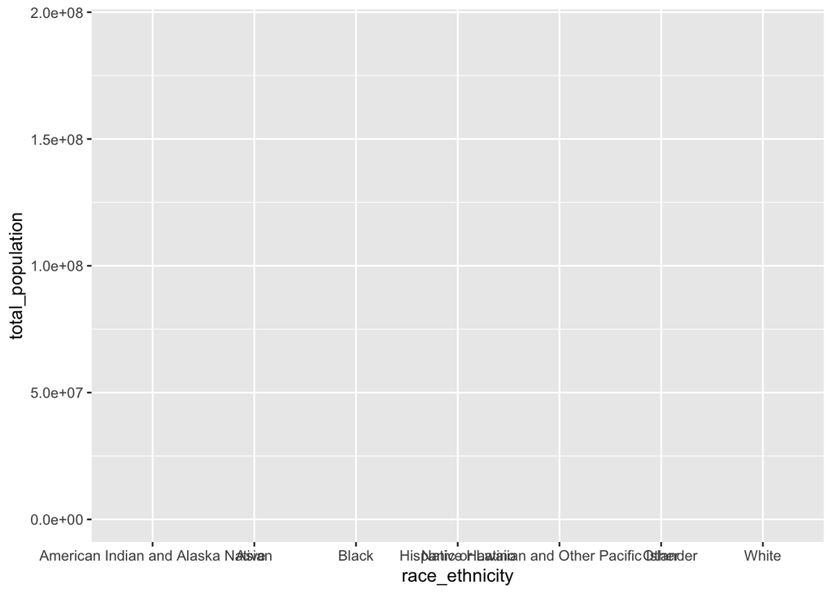

```r
p1 <- ggplot(
  category_population,
  aes(x = race_ethnicity, y = total_population)
)

p1
```

| Plot component | Code in this chunk |
| --- | --- |
| Geoms / stats | `geom_bar()` |

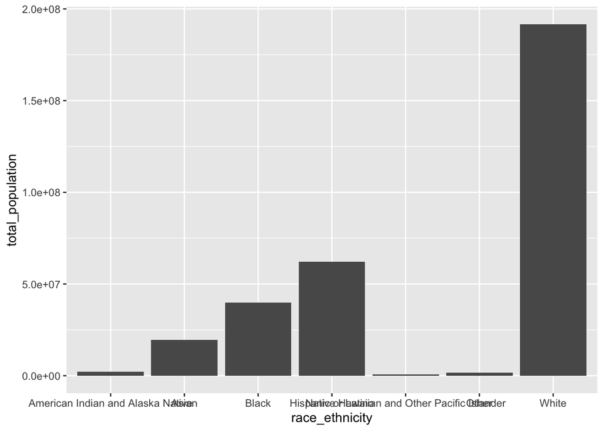

```r
p2 <- p1 +
  geom_bar(stat = "identity")

p2
```

# Order The Categories

The labels are hard to read, and alphabetical order does not help answer the ranking question.

Reorder by total population. This uses `mutate()` to change the category order before plotting.

| Data preparation step | Functions in this chunk |
| --- | --- |
| Create or change columns | `mutate()` |

| Plot component | Code in this chunk |
| --- | --- |
| Aesthetic mappings | `x`; `y` |

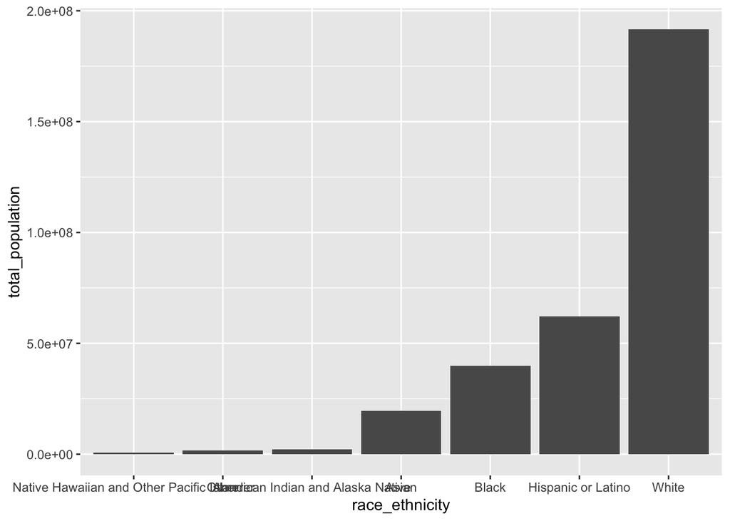

```r
category_population_ordered <- category_population |>
  mutate(race_ethnicity = reorder(race_ethnicity, total_population))

p3 <- ggplot(
  category_population_ordered,
  aes(x = race_ethnicity, y = total_population)
) +
  geom_bar(stat = "identity")

p3
```

Flip the coordinates so the category labels are readable.

| Plot component | Code in this chunk |
| --- | --- |
| Scales / coordinates / facets / labels | `coord_flip()` |

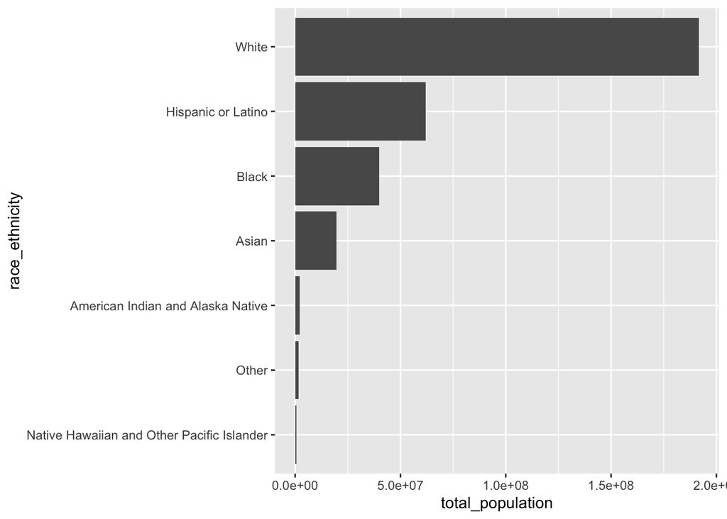

```r
p4 <- p3 +
  coord_flip()

p4
```

Add labels and a theme.

| Plot component | Code in this chunk |
| --- | --- |
| Scales / coordinates / facets / labels | `labs()`; `theme_minimal()` |

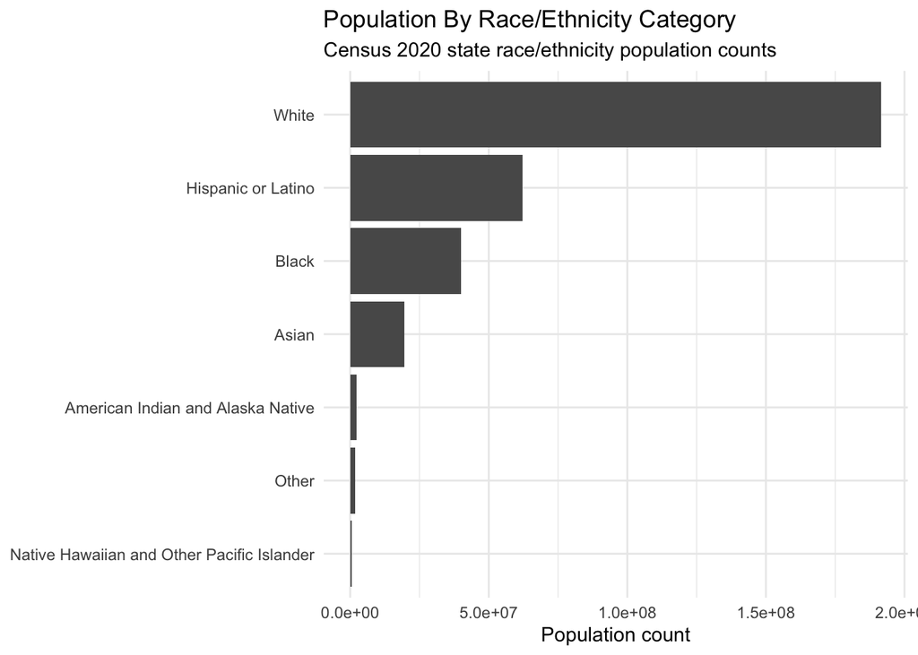

```r
p5 <- p4 +
  labs(
    title = "Population By Race/Ethnicity Category",
    subtitle = "Census 2020 state race/ethnicity population counts",
    x = NULL,
    y = "Population count"
  ) +
  theme_minimal()

p5
```

# Different Geom, Same Information: Lollipop Plots

Bars are common for counts and totals, but they can get visually heavy when there are many categories.

A lollipop plot keeps the same position-on-a-common-scale comparison, but uses less ink.

| Plot component | Code in this chunk |
| --- | --- |
| Aesthetic mappings | `y` |

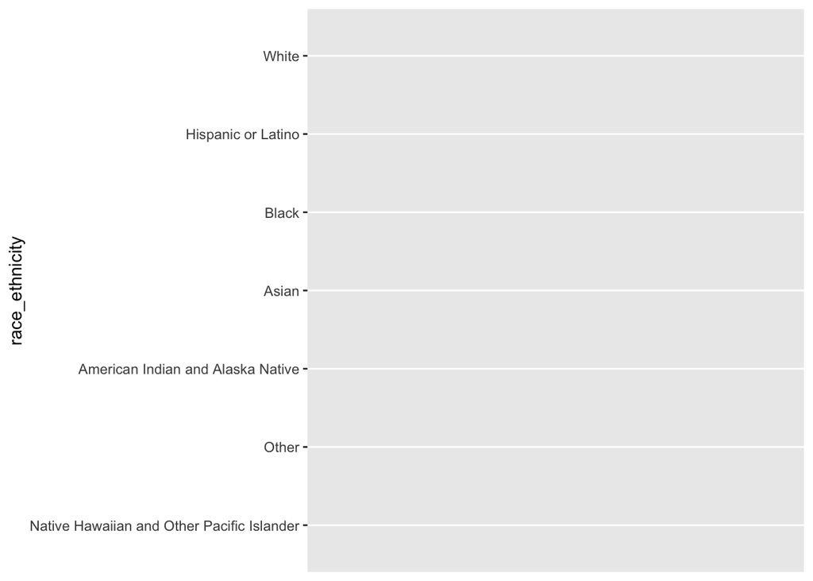

```r
p1 <- ggplot(
  category_population_ordered,
  aes(y = race_ethnicity)
)

p1
```

Add the stems. Each stem runs from zero to the category total.

| Plot component | Code in this chunk |
| --- | --- |
| Aesthetic mappings | `x`; `xend`; `yend` |
| Geoms / stats | `geom_segment()` |

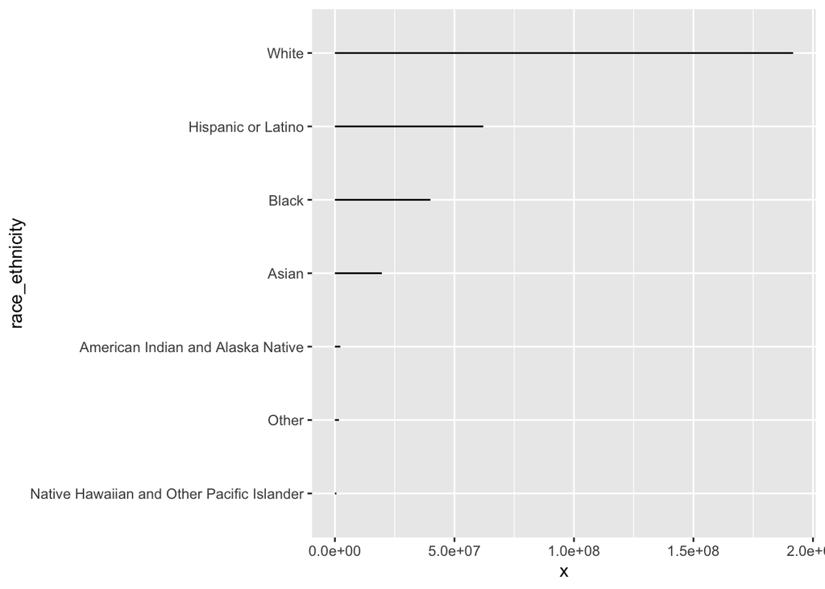

```r
p2 <- p1 +
  geom_segment(
    aes(
      x = 0,
      xend = total_population,
      yend = race_ethnicity
    )
  )

p2
```

Add points at the values.

| Plot component | Code in this chunk |
| --- | --- |
| Aesthetic mappings | `x` |
| Geoms / stats | `geom_point()` |
| `geom_point()` properties | `size` |

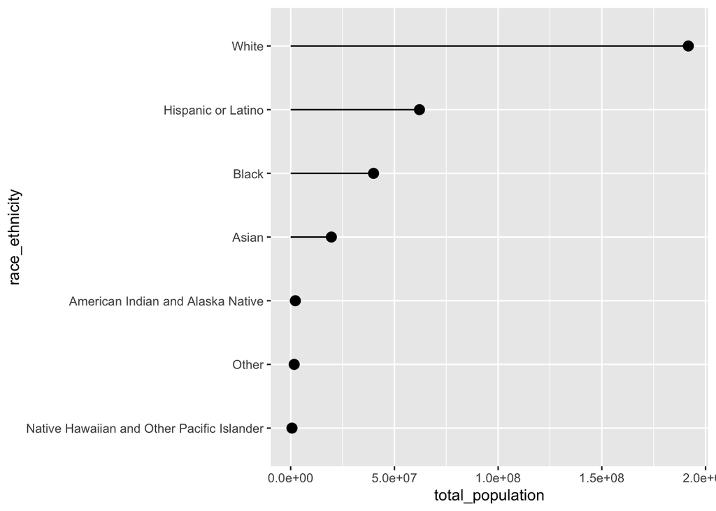

```r
p3 <- p2 +
  geom_point(aes(x = total_population), size = 3)

p3
```

Add labels and a theme.

| Plot component | Code in this chunk |
| --- | --- |
| Scales / coordinates / facets / labels | `labs()`; `theme_minimal()` |

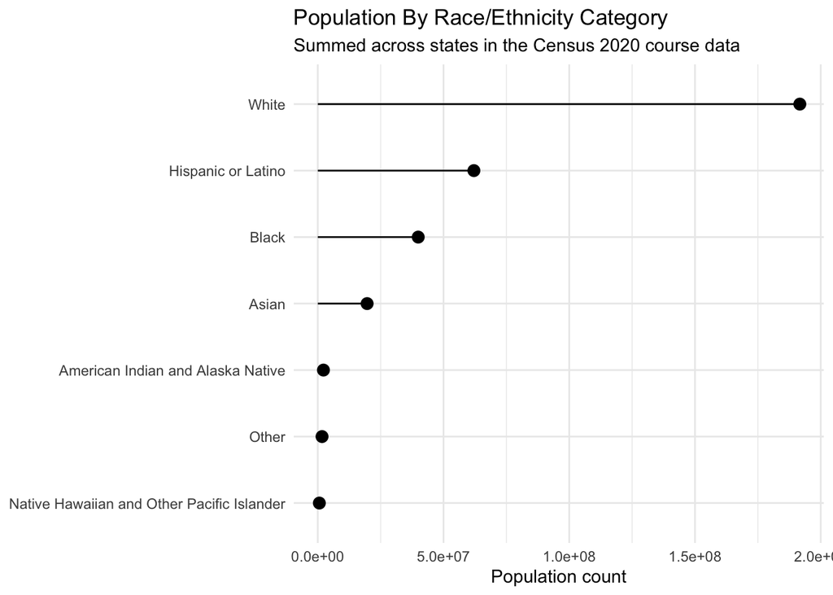

```r
p4 <- p3 +
  labs(
    title = "Population By Race/Ethnicity Category",
    subtitle = "Summed across states in the Census 2020 course data",
    x = "Population count",
    y = NULL
  ) +
  theme_minimal()

p4
```

# Many Categories

The lollipop pattern is especially useful when there are many categories.

Here is one summarized row per state.

| Data preparation step | Functions in this chunk |
| --- | --- |
| Create or change columns | `mutate()` |
| Count or summarize | `group_by()`; `summarize()` |
| Sort rows | `arrange()`; `desc()` |

```r
state_population <- census |>
  group_by(state_name) |>
  summarize(
    total_population = sum(race_ethnicity_population),
    .groups = "drop"
  ) |>
  arrange(desc(total_population)) |>
  mutate(state_name = reorder(state_name, total_population))

state_population |>
  head()
```

```
# A tibble: 6 × 2
  state_name   total_population
  <fct>                   <dbl>
1 California           37910501
2 Texas                28259410
3 Florida              20746044
4 New York             19480402
5 Pennsylvania         12551415
6 Illinois             12397653
```

A bar plot with all 51 states works, but the repeated filled rectangles dominate the figure.

The population values are large, so we also format the axis labels in millions. `scale_y_continuous()` sets the tick locations with `breaks` and changes how those ticks are printed with `labels`.

| Plot component | Code in this chunk |
| --- | --- |
| Aesthetic mappings | `x`; `y` |
| Geoms / stats | `geom_bar()` |
| Scales / coordinates / facets / labels | `coord_flip()`; `scale_y_continuous()`; `labs()`; `theme_minimal()`; `theme()` |

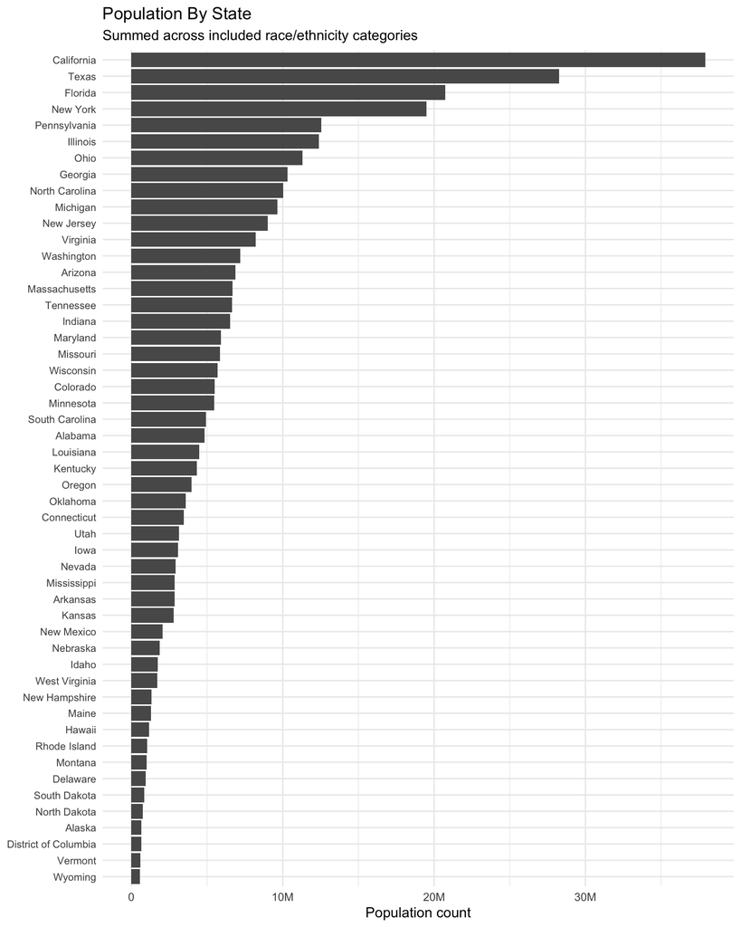

```r
ggplot(state_population, aes(x = state_name, y = total_population)) +
  geom_bar(stat = "identity") +
  coord_flip() +
  scale_y_continuous(
    breaks = seq(0, 40000000, by = 10000000),
    labels = function(x) ifelse(x == 0, "0", paste0(x / 1000000, "M"))
  ) +
  labs(
    title = "Population By State",
    subtitle = "Summed across included race/ethnicity categories",
    x = NULL,
    y = "Population count"
  ) +
  theme_minimal() +
  theme(axis.text.y = element_text(size = 8))
```

We can first remove the filled bars and keep only the line length.

This is basically a bar plot with less visual weight. For many-category rankings, this is often a strong choice.

| Plot component | Code in this chunk |
| --- | --- |
| Aesthetic mappings | `y`; `x`; `xend`; `yend` |
| Geoms / stats | `geom_segment()` |
| Scales / coordinates / facets / labels | `scale_x_continuous()`; `labs()`; `theme_minimal()`; `theme()` |

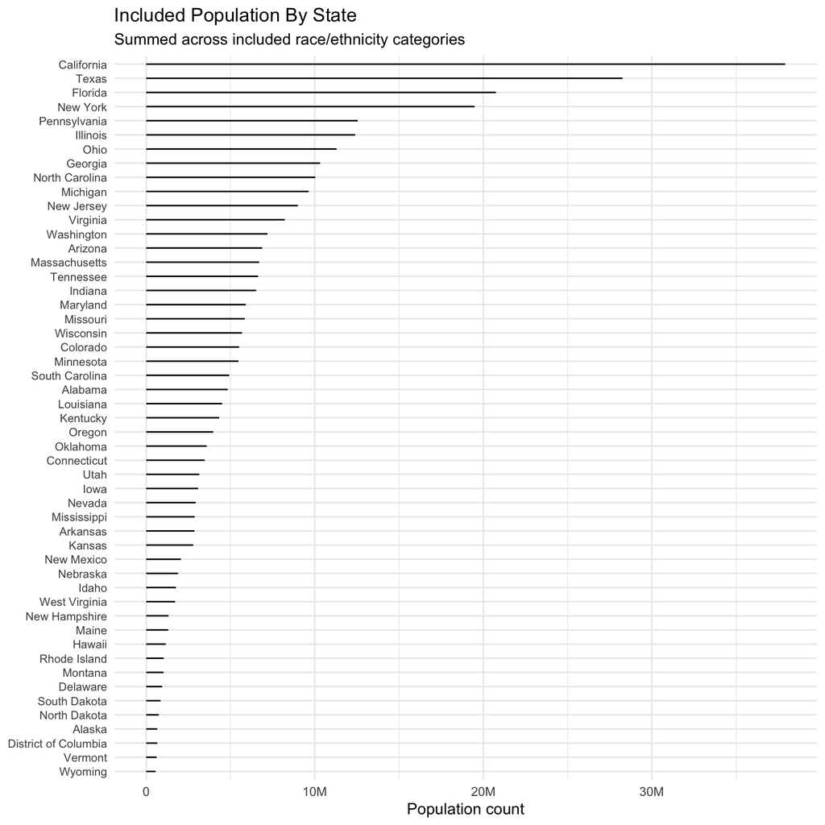

```r
ggplot(state_population, aes(y = state_name)) +
  geom_segment(
    aes(
      x = 0,
      xend = total_population,
      yend = state_name
    )
  ) +
  scale_x_continuous(
    breaks = seq(0, 40000000, by = 10000000),
    labels = function(x) ifelse(x == 0, "0", paste0(x / 1000000, "M"))
  ) +
  labs(
    title = "Included Population By State",
    subtitle = "Summed across included race/ethnicity categories",
    x = "Population count",
    y = NULL
  ) +
  theme_minimal() +
  theme(axis.text.y = element_text(size = 8))
```

Adding points at the ends gives a lollipop plot. The points emphasize the exact values.

| Plot component | Code in this chunk |
| --- | --- |
| Geoms / stats | `geom_segment()`; `geom_point()` |
| `geom_point()` properties | `size` |

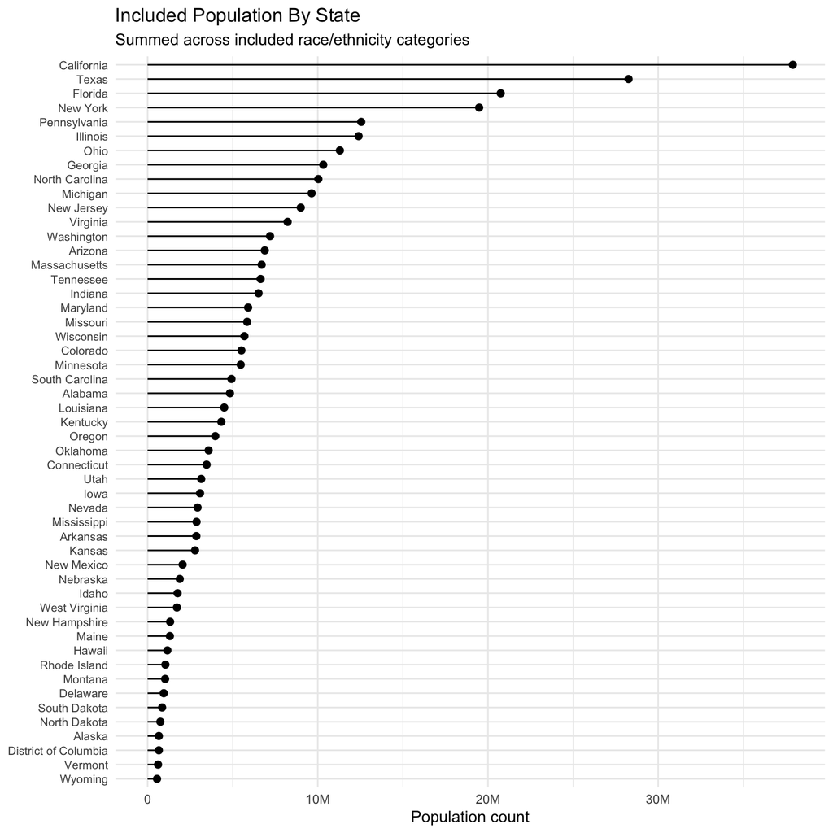

```r
ggplot(state_population, aes(y = state_name)) +
  geom_segment(
    aes(
      x = 0,
      xend = total_population,
      yend = state_name
    )
  ) +
  geom_point(aes(x = total_population), size = 2) +
  scale_x_continuous(
    breaks = seq(0, 40000000, by = 10000000),
    labels = function(x) ifelse(x == 0, "0", paste0(x / 1000000, "M"))
  ) +
  labs(
    title = "Included Population By State",
    subtitle = "Summed across included race/ethnicity categories",
    x = "Population count",
    y = NULL
  ) +
  theme_minimal() +
  theme(axis.text.y = element_text(size = 8))
```

# Takeaways

- Categorical plots depend on what one observation represents.
- `count()` and `geom_bar()` count observations.
- `group_by()` + `summarize()` aggregate values by group.
- `geom_bar(stat = "identity")` uses pre-calculated counts; this pattern is useful for complex data.
- Ordering categories often makes the plot easier to interpret.
- Lollipop plots can be useful when a bar plot has many categories.
- A count of observations is not the same thing as a count of people, events, or cases.